# R Notebook

Reading in the data.

# Begining with ELVS dataset:

## Look at raw data.

```r
elvs %>% glimpse()
```

```
Observations: 308
Variables: 3
$ X1        <int> 1, 2, 3, 4, 5, 6, 7, 8, 9, 10, 11, 12, 13, 14, 15, 16, 17, 18, 19, 20, 21, 22, 23, 24, 25, ...
$ CELF7SS0  <int> 113, 114, 87, 93, 101, 115, 126, 94, 103, 93, 117, 125, 111, 78, 94, 106, 100, 108, 111, 96...
$ rs1916988 <fct> T/T, C/T, T/T, C/T, C/T, T/T, C/C, C/T, C/T, C/T, T/T, C/C, C/T, T/T, T/T, C/T, C/C, C/T, T...
```

FACTOR THE DATA AND CREATE LEVELS TALK TO THE GROUP ABOUT THAT

## Compute Summary stats:

```r
elvs %>% skim()
```

```
Skim summary statistics
 n obs: 308
 n variables: 3

-- Variable type:factor --------------------------------------------------------
  variable missing complete   n n_unique                         top_counts ordered
 rs1916988       0      308 308        3 C/T: 144, T/T: 133, C/C: 31, NA: 0   FALSE

-- Variable type:integer -------------------------------------------------------
 variable missing complete   n   mean    sd p0   p25   p50    p75 p100     hist
 CELF7SS0       0      308 308  99.04 14.08 45 91    100   108     134 ▁▁▂▃▇▆▃▁
       X1       0      308 308 154.5  89.06  1 77.75 154.5 231.25  308 ▇▇▇▇▇▇▇▇
```

# Visualizations:

Lets see the distribution of the celf scores…

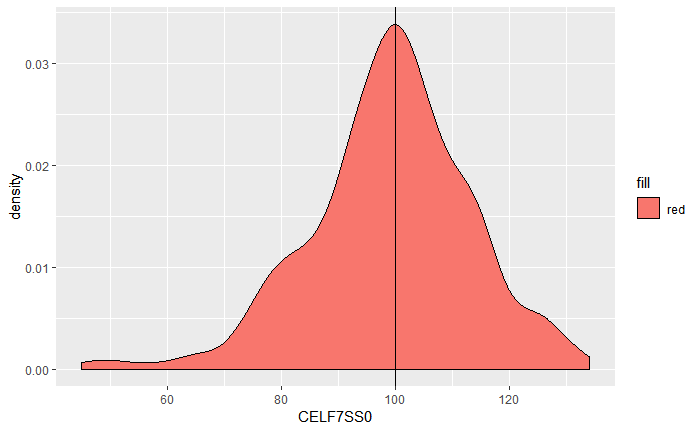

Here we can see that the sample mean of the CELF score is centered around 100. We can notice that there is there is a significant left skew to the distribution indicating we have a larger proportion of low scores present in this data set, which is completely reasonable since we our hypothesis is that there a mutation in foxp2 will lower langauge ability.

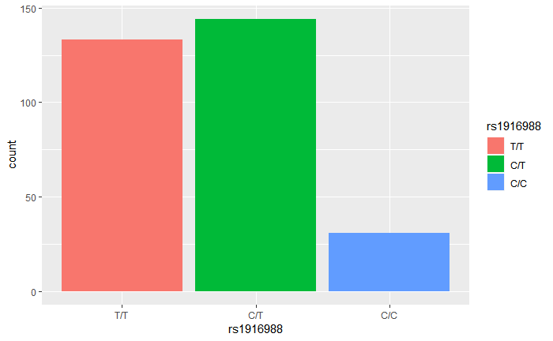

Here we can see that there is a higher count of C/T in the dataset than any other variant. Additionally there is a very small proportion of C/C which I assume is the rare variant causing some damage.

# GUYS WE CARE ABOUT A 0 VALUE IN THESE DATASET SINCE IF THE GENE IS HECKIN KNOCKED OUT WE SHOULD SEE A DECREASE IN LANGUAGE SCORES HECKIN HECK MAN

# IOWA DATA:

## Look at raw values

```r
iowa %>% glimpse()
```

```
Observations: 834
Variables: 17
$ X1         <int> 1, 2, 3, 4, 5, 6, 7, 8, 9...
$ ID         <chr> "23409001", "23409002", "...
$ LCOMP      <dbl> 0.47362404, -0.86215342, ...
$ Sample     <chr> "School", "School", "Scho...
$ rs7791396  <fct> C/G, C/G, C/C, C/C, C/G, ...
$ rs12155328 <fct> C/T, T/T, C/C, C/C, C/T, ...
$ rs10447760 <fct> C/C, C/C, 0/0, C/C, C/C, ...
$ rs10953754 <fct> A/G, A/A, A/G, A/A, A/A, ...
$ rs2244419  <fct> C/C, C/C, C/C, C/C, C/C, ...
$ rs1668335  <fct> G/G, G/A, G/A, G/A, G/G, ...
$ rs2396720  <fct> C/C, C/C, C/C, C/C, C/C, ...
$ rs1916988  <fct> T/T, T/C, T/C, T/C, T/T, ...
$ rs11505922 <fct> C/T, C/C, C/C, C/T, T/T, ...
$ rs7785701  <fct> C/G, G/G, C/G, G/G, C/C, ...
$ rs2106900  <fct> G/G, A/A, G/A, A/A, G/G, ...
$ rs7799652  <fct> G/T, G/T, G/T, G/T, G/G, ...
$ rs1005958  <fct> T/C, C/C, C/C, 0/0, T/C, ...
```

## Summary Statistics:

```r
iowa %>% skim()
```

```
Skim summary statistics
 n obs: 834
 n variables: 17

-- Variable type:character -----------------------------------------------------
 variable missing complete   n min max empty
       ID       0      834 834   8  12     0
   Sample       0      834 834   6  12     0
 n_unique
      834
        2

-- Variable type:factor --------------------------------------------------------
   variable missing complete   n n_unique
  rs1005958       0      834 834        4
 rs10447760       0      834 834        4
 rs10953754       0      834 834        4
 rs11505922       0      834 834        4
 rs12155328       0      834 834        4
  rs1668335       0      834 834        4
  rs1916988       0      834 834        4
  rs2106900       0      834 834        4
  rs2244419       0      834 834        4
  rs2396720       0      834 834        3
  rs7785701       0      834 834        4
  rs7791396       0      834 834        4
  rs7799652       0      834 834        4
                            top_counts ordered
 T/C: 393, T/T: 222, C/C: 165, 0/0: 54   FALSE
  C/C: 456, C/T: 278, T/T: 52, 0/0: 48   FALSE
 A/G: 390, A/A: 282, G/G: 113, 0/0: 49   FALSE
 C/T: 407, T/T: 218, C/C: 185, 0/0: 24   FALSE
 C/T: 336, C/C: 245, T/T: 166, 0/0: 87   FALSE
  G/A: 365, G/G: 364, A/A: 80, 0/0: 25   FALSE
  T/C: 366, T/T: 354, C/C: 79, 0/0: 35   FALSE
 G/A: 375, G/G: 245, A/A: 175, 0/0: 39   FALSE
   C/C: 689, C/T: 121, 0/0: 19, T/T: 5   FALSE
     C/C: 787, A/C: 24, 0/0: 23, NA: 0   FALSE
 C/G: 376, G/G: 252, C/C: 167, 0/0: 39   FALSE
 C/G: 368, C/C: 299, G/G: 105, 0/0: 62   FALSE
 G/T: 382, T/T: 210, G/G: 184, 0/0: 58   FALSE

-- Variable type:integer -------------------------------------------------------
 variable missing complete   n  mean    sd p0
       X1       0      834 834 417.5 240.9  1
    p25   p50    p75 p100     hist
 209.25 417.5 625.75  834 ▇▇▇▇▇▇▇▇

-- Variable type:numeric -------------------------------------------------------
 variable missing complete   n  mean   sd    p0
    LCOMP       0      834 834 -0.35 1.09 -3.45
   p25   p50  p75 p100     hist
 -1.21 -0.37 0.47 2.59 ▁▂▇▇▇▇▃▁
```

Here we can see that the LCOMP mean is -0.35. This initial finding follows our hypothesis that a mutation in foxp2 is associated with a decrease in language ability. Unfortunatly when we take into account the standard deviation we see that it overlaps with 0 giving us a quick and dirty metric that something is afoot.

## Visualizations

Lanuage Scores:

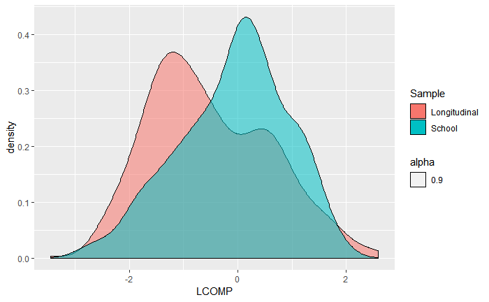

```r
iowa %>% ggplot(aes(x=LCOMP,fill=Sample,alpha=.9)) + geom_density()
```

```r
iowa %>% ggplot(aes(x="rs1916988",fill = rs1916988, alpha = .9)) + geom_bar()
```

[output not shown]

```r
SNP <- iowa %>% gather(key = "SNP", value = "Geno", starts_with("rs")) %>% group_by(SNP)
```

```
attributes are not identical across measure variables;
they will be dropped
```

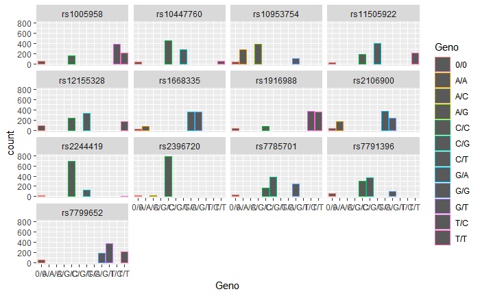

```r
SNP %>% ggplot(aes(x = Geno, color = Geno)) + geom_bar() + facet_wrap(~SNP)
```

```r
LONG <-  SNP %>% group_by(SNP) %>% distinct(Geno) %>% ungroup(SNP)
SPREAD <- LONG %>% group_by_at(vars(-Geno)) %>% mutate(id = 1:n()) %>% ungroup() %>% spread(SNP,Geno)
```

```r
#Select SNPS
variables <- colnames(iowa)[startsWith(colnames(iowa),"rs")]
new_tab <- iowa %>% select(starts_with("rs"))
n <-length(new_tab)
print(n)
```

```
[1] 13
```

```r
SNP_var <- iowa
p = ggplot()
for (i in 1:n)
  {
  data <- new_tab %>% pull(i)
   p + qplot(data, data = new_tab, geom = "bar")

}
```

```
Error: Don't know how to add qplot(data, data = new_tab, geom = "bar") to a plot
```